# Project 1

```python
import numpy as np
import pandas as pd
import seaborn as sns
import matplotlib.pyplot as plt
```

## Introduction

This dataset comes from [Delaware Open Data](https://data.delaware.gov/)

The Educator Avegare Salary dataset "...contains average total, federal, state, and local salaries for full-time staff. In addition, this file provides the number of full-time equivalent positions in each organization, average years of experience, as well as average years of age. Data is aggregated at the state, district, and school level" ([Educator Average Salary](https://data.delaware.gov/Education/Educator-Average-Salary/rv4m-vy79/data_preview)).

```python
salaries = pd.read_csv('Educator_Average_Salary_20240314.csv')
salaries.head()
```

|  | School Year | District Code | District | School Code | Organization | Race | Gender | Grade | SpecialDemo | Geography | ... | Staff Category | Job Classification | Experience | Educators (FTE) | Average Total Salary | Average State Salary | Average Local Salary | Average Federal Salary | Average Years of Experience | Average Years of Age |
| --- | --- | --- | --- | --- | --- | --- | --- | --- | --- | --- | --- | --- | --- | --- | --- | --- | --- | --- | --- | --- | --- |
| 0 | 2020 | 24 | Smyrna School District | 697 | Smyrna Administrative Office | White | All Educators | All Educators | Regular | All Educators | ... | Official/Administrative | ALL | ALL | 14.0 | 95625.22 | 54023.65 | 41601.56 | NaN | 19 | 53 |
| 1 | 2020 | 24 | Smyrna School District | 697 | Smyrna Administrative Office | White | All Educators | All Educators | Regular | All Educators | ... | Pupil Support | ALL | ALL | 1.0 | 97917.55 | 60056.88 | 37860.68 | NaN | 1 | 33 |
| 2 | 2020 | 24 | Smyrna School District | 697 | Smyrna Administrative Office | White | All Educators | All Educators | All Educators | All Educators | ... | ALL | ALL | ALL | 25.0 | 48982.63 | 35892.53 | 13090.10 | NaN | 20 | 46 |
| 3 | 2020 | 24 | Smyrna School District | 697 | Smyrna Administrative Office | White | All Educators | All Educators | Regular | All Educators | ... | Instructional Support | Supervisor, Instructional | ALL | 3.0 | 115362.61 | 64883.95 | 50478.65 | NaN | 12 | 53 |
| 4 | 2020 | 24 | Smyrna School District | 697 | Smyrna Administrative Office | White | All Educators | All Educators | All Educators | All Educators | ... | ALL | ALL | ALL | 46.0 | 69886.27 | 44649.62 | 25236.64 | NaN | 19 | 48 |

5 rows × 22 columns

## Preprocessing

```python
#Drop unimportant columns
salaries = salaries.drop(columns = ['School Year', 'District Code', 'Geography', 'Organization', 'Grade', 'Average Federal Salary', 'Job Classification', 'Experience', 'Educators (FTE)', 'School Code'], axis = 1)
#Drop rows with missing values
salaries = salaries.dropna()
#Drop rows with "All Educators" and "ALL" as a value in all columns
salaries = salaries[salaries['Race'] != 'All Educators']
salaries = salaries[salaries['Gender'] != 'All Educators']
salaries = salaries[salaries['SpecialDemo'] != 'All Educators']
salaries = salaries[salaries['Staff Category'] != 'ALL']
#Remove columns where Average Years of Age is above 90
salaries = salaries[salaries['Average Years of Age'] < 90]
#Show data after preprocessing
salaries
```

|  | District | Race | Gender | SpecialDemo | SubGroup | Staff Type | Staff Category | Average Total Salary | Average State Salary | Average Local Salary | Average Years of Experience | Average Years of Age |
| --- | --- | --- | --- | --- | --- | --- | --- | --- | --- | --- | --- | --- |
| 81 | Smyrna School District | White | Female | Regular | White/Female/Regular School | Non-Professional | Skilled & Service Workers | 36488.92 | 36228.66 | 260.26 | 11 | 62 |
| 82 | Smyrna School District | White | Female | Regular | White/Female/Regular School | Professional | Official/Administrative | 111156.76 | 48856.86 | 62299.90 | 18 | 63 |
| 87 | Smyrna School District | White | Female | Regular | White/Female/Regular School | Professional | Instructional Support | 118001.52 | 67360.28 | 50641.24 | 10 | 59 |
| 89 | Smyrna School District | White | Female | Regular | White/Female/Regular School | Non-Professional | Skilled & Service Workers | 18626.92 | 18366.92 | 260.00 | 5 | 43 |
| 90 | Smyrna School District | White | Female | Regular | White/Female/Regular School | Professional | Official/Administrative | 141327.94 | 80867.80 | 60460.14 | 9 | 41 |
| ... | ... | ... | ... | ... | ... | ... | ... | ... | ... | ... | ... | ... |
| 2394070 | Sussex Montessori School | African American | Female | Charter | African American/Female/Charter School | Professional | Official/Administrative | 48125.00 | 80000.00 | 16250.00 | 5 | 75 |
| 2394192 | Sussex Montessori School | White | Female | Charter | White/Female/Charter School | Professional | Classroom Teacher | 62172.58 | 59762.03 | 33747.74 | 14 | 84 |
| 2394214 | Sussex Montessori School | White | Female | Charter | White/Female/Charter School | Professional | Classroom Teacher | 63456.74 | 60388.76 | 33747.74 | 14 | 81 |
| 2394235 | Sussex Montessori School | White | Female | Charter | White/Female/Charter School | Professional | Classroom Teacher | 66453.93 | 59704.38 | 33747.74 | 19 | 55 |
| 2394245 | Sussex Montessori School | White | Female | Charter | White/Female/Charter School | Professional | Classroom Teacher | 67044.94 | 61420.32 | 33747.74 | 22 | 67 |

252162 rows × 12 columns

### Outlier Analysis

How many outliers are there per quantitative column?

```python
def count_outliers(column):
    Q25 = column.quantile(0.25)
    Q75 = column.quantile(0.75)
    IQR = Q75 - Q25
    lower_bound = Q25 - 1.5 * IQR
    upper_bound = Q75 + 1.5 * IQR
    outliers = column[(column < lower_bound) | (column > upper_bound)]
    return len(outliers)


#Outliers of Average Total Salary
print("Average Total Salary: \nTotal number of salaries: ")
print(len(salaries['Average Total Salary']))
av_total = count_outliers(salaries['Average Total Salary'])
print("Number of outliers: ")
print(av_total)
print("\n")

#Outliers of Average State Salary
print("Average State Salary: \nTotal number of salaries: ")
print(len(salaries['Average State Salary']))
av_state = count_outliers(salaries['Average State Salary'])
print("Number of outliers: ")
print(av_state)
print("\n")

#Outliers of Average Local Salary
print("Average Local Salary: \nTotal number of salaries: ")
print(len(salaries['Average Local Salary']))
av_local = count_outliers(salaries['Average Local Salary'])
print("Number of outliers: ")
print(av_local)
print("\n")

#Outliers of Average Years of Experience
print("Average Years of Experience: \nTotal number of employees: ")
print(len(salaries['Average Years of Experience']))
av_exp = count_outliers(salaries['Average Years of Experience'])
print("Number of outliers: ")
print(av_exp)
print("\n")

#Outliers of Average Years of Age
print("Average Years of Age: \nTotal number of employees: ")
print(len(salaries['Average Years of Age']))
av_age = count_outliers(salaries['Average Years of Age'])
print("Number of outliers: ")
print(av_age)
```

```
Average Total Salary:
Total number of salaries:
252162
Number of outliers:
6734


Average State Salary:
Total number of salaries:
252162
Number of outliers:
3582


Average Local Salary:
Total number of salaries:
252162
Number of outliers:
12618


Average Years of Experience:
Total number of employees:
252162
Number of outliers:
1719


Average Years of Age:
Total number of employees:
252162
Number of outliers:
1845
```

What is the mean of each quantitative column with/without the outliers?

```python
def remove_outliers(df, column):
    Q25 = df[column].quantile(0.25)
    Q75 = df[column].quantile(0.75)
    IQR = Q75 - Q25
    lower_bound = Q25 - 1.5 * IQR
    upper_bound = Q75 + 1.5 * IQR
    df = df[(df[column] >= lower_bound) & (df[column] <= upper_bound)]
    return df

#Mean of Average Total Salary
mean_total = salaries['Average Total Salary'].mean()
print("Mean of Average Total Salary: ")
print(mean_total)
print("Mean of Average Total Salary without outliers: ")
no_outliers_total = remove_outliers(salaries, 'Average Total Salary')
print(no_outliers_total['Average Total Salary'].mean())
print("\n")

#Mean of Average State Salary
mean_state = salaries['Average State Salary'].mean()
print("Mean of Average State Salary: ")
print(mean_state)
print("Mean of Average State Salary without outliers: ")
no_outliers_state = remove_outliers(salaries, 'Average State Salary')
print(no_outliers_state['Average State Salary'].mean())
print("\n")

#Mean of Average Local Salary
mean_local = salaries['Average Local Salary'].mean()
print("Mean of Average Local Salary: ")
print(mean_local)
print("Mean of Average Local Salary without outliers: ")
no_outliers_local = remove_outliers(salaries, 'Average Local Salary')
print(no_outliers_local['Average Local Salary'].mean())
print("\n")

#Mean of Average Years of Experience
mean_exp = salaries['Average Years of Experience'].mean()
print("Mean of Average Years of Experience: ")
print(mean_exp)
print("Mean of Average Years of Experience without outliers: ")
no_outliers_exp = remove_outliers(salaries, 'Average Years of Experience')
print(no_outliers_exp['Average Years of Experience'].mean())
print("\n")

#Mean of Average Years of Age
mean_age = salaries['Average Years of Age'].mean()
print("Mean of Average Years of Age: ")
print(mean_age)
print("Mean of Average Years of Age without outliers: ")
no_outliers_age = remove_outliers(salaries, 'Average Years of Age')
print(no_outliers_age['Average Years of Age'].mean())
```

```
Mean of Average Total Salary:
61888.90926900167
Mean of Average Total Salary without outliers:
59646.94134719754


Mean of Average State Salary:
39408.56654012103
Mean of Average State Salary without outliers:
38795.52753210234


Mean of Average Local Salary:
23875.800026490906
Mean of Average Local Salary without outliers:
21474.23220435494


Mean of Average Years of Experience:
14.356937207033573
Mean of Average Years of Experience without outliers:
14.16898855228535


Mean of Average Years of Age:
44.64913032098413
Mean of Average Years of Age without outliers:
44.544781217416315
```

What is the median of each quantitative column with/without outliers?

```python
#Median of Average Total Salary
median_total = salaries['Average Total Salary'].median()
print("Median of Average Total Salary: ")
print(median_total)
print("Median of Average Total Salary without outliers: ")
print(no_outliers_total['Average Total Salary'].median())
print("\n")

#Median of Average State Salary
median_state = salaries['Average State Salary'].median()
print("Median of Average State Salary: ")
print(median_state)
print("Median of Average State Salary without outliers: ")
print(no_outliers_state['Average State Salary'].median())
print("\n")

#Median of Average Local Salary
median_local = salaries['Average Local Salary'].median()
print("Median of Average Local Salary: ")
print(median_local)
print("Median of Average Local Salary without outliers: ")
print(no_outliers_local['Average Local Salary'].median())
print("\n")

#Median of Average Years of Experience
median_exp = salaries['Average Years of Experience'].median()
print("Median of Average Years of Experience: ")
print(median_exp)
print("Median of Average Years of Experience without outliers: ")
print(no_outliers_exp['Average Years of Experience'].median())
print("\n")

#Median of Average Years of Age
median_age = salaries['Average Years of Age'].median()
print("Median of Average Years of Age: ")
print(median_age)
print("Median of Average Years of Age without outliers: ")
print(no_outliers_age['Average Years of Age'].median())
```

```
Median of Average Total Salary:
58078.255
Median of Average Total Salary without outliers:
57059.08


Median of Average State Salary:
38071.67
Median of Average State Salary without outliers:
37766.03999999999


Median of Average Local Salary:
19985.254999999997
Median of Average Local Salary without outliers:
19137.82


Median of Average Years of Experience:
14.0
Median of Average Years of Experience without outliers:
14.0


Median of Average Years of Age:
45.0
Median of Average Years of Age without outliers:
45.0
```

## Summary Data Analysis

### Statistical summaries of each column:

```python
#Number of rows from each district
districts = salaries['District'].value_counts()
print("Number of rows from each district: ")
print(districts)
```

```
Number of rows from each district:
District
Christina School District                                 32210
Red Clay Consolidated School District                     30311
Brandywine School District                                20579
Colonial School District                                  19747
Appoquinimink School District                             19426
Indian River School District                              16503
Capital School District                                   15618
Caesar Rodney School District                             14592
Cape Henlopen School District                             11805
Smyrna School District                                    10115
State of Delaware                                          9055
Seaford School District                                    8654
Lake Forest School District                                7768
New Castle County Vocational-Technical School District     7507
Milford School District                                    7417
Woodbridge School District                                 5723
Laurel School District                                     5011
POLYTECH School District                                   2840
Sussex Technical School District                           2744
Delmar School District                                     2569
Odyssey Charter School                                      316
Newark Charter School                                       292
Las Americas Aspira Academy                                 230
Providence Creek Academy Charter School                     204
Academia Antonia Alonso                                     204
East Side Charter School                                    150
Consortium Discipline Alternative Programs                   56
Academy of Dover Charter School                              54
Charter School of New Castle                                 50
Edison (Thomas A.) Charter School                            46
Sussex Academy                                               44
First State Montessori Academy                               40
Kuumba Academy Charter School                                32
Delaware Academy of Public Safety and Security               32
Gateway Lab School                                           28
Campus Community Charter School                              28
Early College High School at Del State                       24
Sussex Academy of Arts & Sciences                            20
Freire Charter School Wilmington                             16
Campus Community School                                      16
MOT Charter School                                           16
Sussex Montessori School                                     12
Family Foundations Academy                                   10
Moyer (Maurice J.) Academy                                    8
Reach Academy for Girls                                       8
First State Military Academy                                  8
Gateway Charter School                                        8
Great Oaks Charter School                                     8
Positive Outcomes Charter School                              8
Name: count, dtype: int64
```

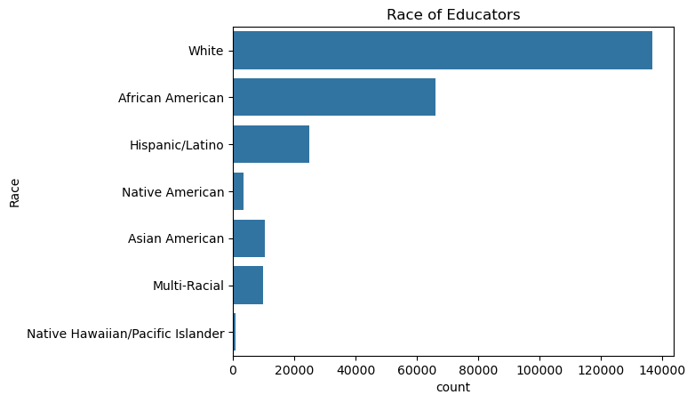

```python
#Bar graph of races of educators
sns.countplot(y = 'Race', data = salaries)
plt.title('Race of Educators')
plt.show()
```

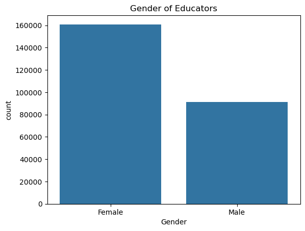

```python
#Bar graph of genders of educators
sns.countplot(x = 'Gender', data = salaries)
plt.title('Gender of Educators')
plt.show()
```

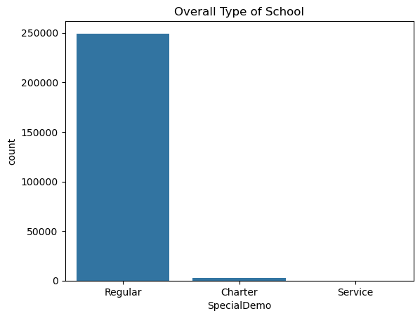

```python
#Overall type of school
sns.countplot(x = 'SpecialDemo', data = salaries)
plt.title('Overall Type of School')
plt.show()
```

```python
#Specific type of school
subgroup = salaries['SubGroup'].value_counts()
print("Number of rows from each subgroup: ")
print(subgroup)
```

```
Number of rows from each subgroup:
SubGroup
White/Female/Regular School                               86961
White/Male/Regular School                                 48223
African American/Female/Regular School                    38551
African American/Male/Regular School                      26715
Hispanic/Latino/Female/Regular School                     16581
Hispanic/Latino/Male/Regular School                        7790
Multi-Racial/Female/Regular School                         6957
Asian American/Female/Regular School                       6914
Asian American/Male/Regular School                         3306
Multi-Racial/Male/Regular School                           3000
Native American/Female/Regular School                      2172
Native American/Male/Regular School                        1315
White/Female/Charter School                                1085
Native Hawaiian/Pacific Islander/Female/Regular School      587
African American/Female/Charter School                      492
Hispanic/Latino/Female/Charter School                       427
White/Male/Charter School                                   401
African American/Male/Charter School                        191
Native Hawaiian/Pacific Islander/Male/Regular School        181
Hispanic/Latino/Male/Charter School                         131
Asian American/Female/Charter School                         96
White/Male/Service School                                    48
White/Female/Service School                                  36
Multi-Racial/Female/Charter School                            2
Name: count, dtype: int64
```

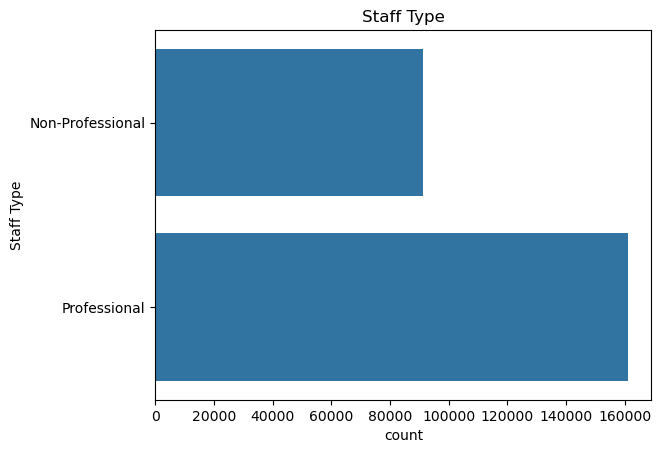

```python
#Graph of type of staff types
sns.countplot(y = 'Staff Type', data = salaries)
plt.title('Staff Type')
plt.show()
```

```python
#Types of staff categories
staff_cat = salaries['Staff Category'].value_counts()
print("Number of rows from each staff category: ")
print(staff_cat)
```

```
Number of rows from each staff category:
Staff Category
Skilled & Service Workers    91151
Classroom Teacher            73516
Official/Administrative      31952
Pupil Support                28821
Instructional Support        26722
Name: count, dtype: int64
```

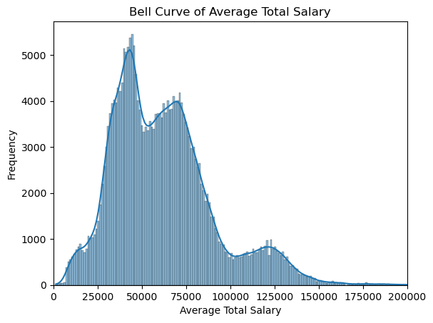

```python
#Graph of Average Total Salary
sns.histplot(data=salaries, x='Average Total Salary', kde=True)
plt.title('Bell Curve of Average Total Salary')
plt.xlabel('Average Total Salary')
plt.ylabel('Frequency')
plt.xlim(0, 200000)  # Set the x-axis limits
plt.show()
```

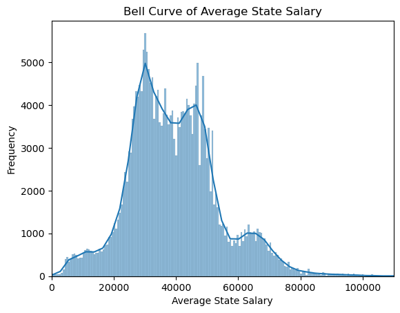

```python
#Graph of Average State Salary
sns.histplot(data=salaries, x='Average State Salary', kde=True)
plt.title('Bell Curve of Average State Salary')
plt.xlabel('Average State Salary')
plt.ylabel('Frequency')
plt.xlim(0, 110000)  # Set the x-axis limits
plt.show()
```

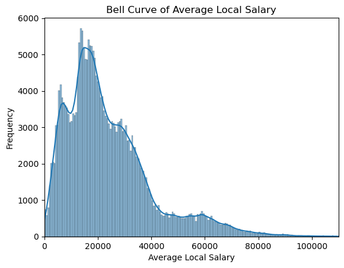

```python
#Graph of Average Local Salary
sns.histplot(data=salaries, x='Average Local Salary', kde=True)
plt.title('Bell Curve of Average Local Salary')
plt.xlabel('Average Local Salary')
plt.ylabel('Frequency')
plt.xlim(0, 110000)  # Set the x-axis limits
plt.show()
```

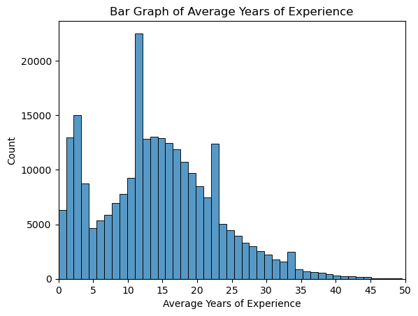

```python
#Bar Graph of Average Years of Experience
sns.histplot(data=salaries, x='Average Years of Experience', bins=50)
plt.title('Bar Graph of Average Years of Experience')
plt.xlabel('Average Years of Experience')
plt.ylabel('Count')
plt.xticks(np.arange(0, 55, 5))  # Increment x-axis by 5
plt.xlim(0, 50)  # Set the x-axis limits
plt.show()
```

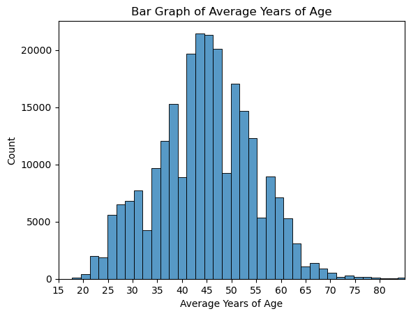

```python
#Bar Graph of Average Years of Age
sns.histplot(data=salaries, x='Average Years of Age', bins=50)
plt.title('Bar Graph of Average Years of Age')
plt.xlabel('Average Years of Age')
plt.ylabel('Count')
plt.xticks(np.arange(0, 85, 5))  # Increment x-axis by 5
plt.xlim(15, 85)  # Set the x-axis limits
plt.show()
```

### Correlations between quantative columns:

The following types of correlation are determined by referencing [tastylive.com](https://www.tastylive.com/concepts-strategies/correlation#:~:text=Positive%20correlation%20is%20measured%20on,correlation%20from%200.5%20to%201.0.)

Average Years of Age vs Average Years of Experience (without outliers)

As expressed below, there is a strong positive correlation between Average Years of Age and Average Years of Experience.

```python
#What is the correlation between the Average Years of Experience and the Average Years of Age without outliers?
correlation = no_outliers_exp['Average Years of Experience'].corr(no_outliers_age['Average Years of Age'])
correlation
```

```
0.6459053973070046
```

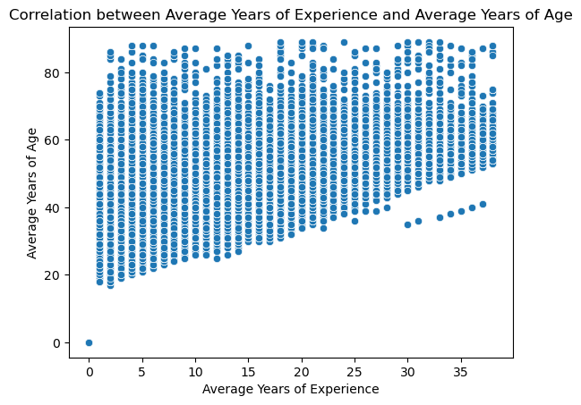

```python
#Graph correlation between Average Years of Experience and Average Years of Age
sns.scatterplot(data=no_outliers_exp, x='Average Years of Experience', y='Average Years of Age')
plt.title('Correlation between Average Years of Experience and Average Years of Age')
plt.xlabel('Average Years of Experience')
plt.ylabel('Average Years of Age')
plt.show()
```

Average Years of Experience vs Average State Salary (without outliers)

```python
#What is the correlation between the Average State Salary and the Average Years of Experience?
correlation = no_outliers_state['Average State Salary'].corr(no_outliers_exp['Average Years of Experience'])
correlation
```

```
0.30746354921640684
```

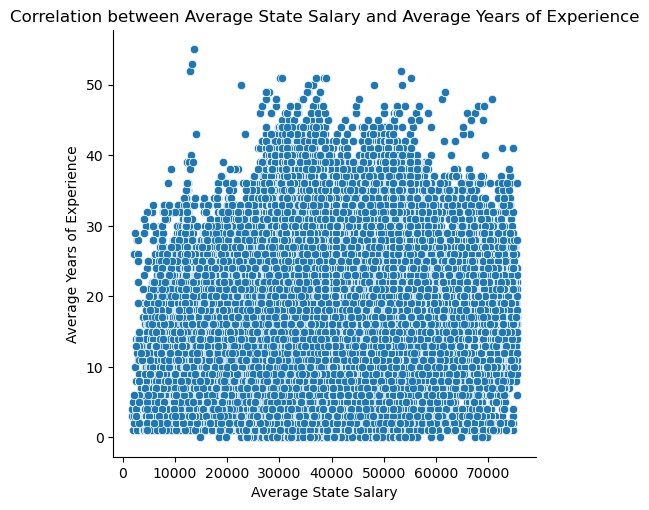

```python
#Graph correlation between Average State Salary and Average Years of Experience
sns.relplot(data=no_outliers_state, x='Average State Salary', y='Average Years of Experience', kind = 'scatter')
plt.title('Correlation between Average State Salary and Average Years of Experience')
plt.xlabel('Average State Salary')
plt.ylabel('Average Years of Experience')
plt.show()
```

Average Years of Age vs Average State Salary (without outliers)

As expressed below, there is no correlation between Average Years of Age and Average State Salary.

```python
#What is the correlation between the Average Years of Age and the Average State Salary?
correlation = no_outliers_age['Average Years of Age'].corr(no_outliers_state['Average State Salary'])
correlation
```

```
0.08432497989189496
```

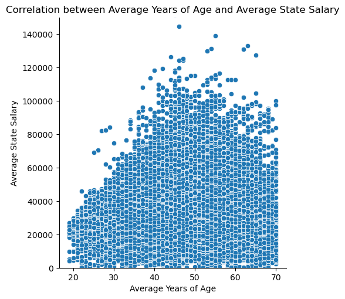

```python
#Graph correlation between Average Years of Age and Average State Salary
sns.relplot(data=no_outliers_age, x='Average Years of Age', y='Average State Salary', kind = 'scatter')
plt.title('Correlation between Average Years of Age and Average State Salary')
plt.xlabel('Average Years of Age')
plt.ylabel('Average State Salary')
plt.ylim(0, 150000)
plt.show()
```

## Discussion Questions

### 1. Qualitative Outcome: Overall, does the race, gender, district, and staff category of an educator predict what subgroup of school they work at?

### 2. Quantitative Outcome: Does the subgroup of a school, as well as gender, race, and years of experience of an educator predict how much more an educator's Average Total Salary will be?